# Impact of public library resources on K-12 learning outcomes in the state of Kansas - 2019

Published

December 10, 2023

Use the Tidyverse dialect of R for data wrangling:

```r
library(tidyverse)
```

## Sources of original data files:

The poverty rates are in a file that was generated (after specified inputs) and downloaded from Census web site, American Community Survey 5 year estimates (2017-2021), from this site: https://data.census.gov/table?g=040XX00US20&y=2021

Original file name (assigned by Census site) is ACSST5Y2021.S1701_Data.csv. For this and all other files, all manipulations are done with the code in this file. ACS 5y estimates 2021 (so 2017-2021); school districts in Kansas.

Geographic Information files grf19_lea_tract.csv census tracts for school districts, 2019 Actually end up usingsing

2015_2022_ACT_Full.csv ACT scores per school and district, 2015-2022 https://ksreportcard.ksde.org/act_scores.aspx?org_no=State&rptType=

US Dept Edu collects State assessments in Reading/Language Arts and Math. The website for downloading data is here: https://www2.ed.gov/about/inits/ed/edfacts/data-files/index.html

From above, downloaded reading data set at district level for 2018-2019 school year (before pandemic) There is wide and long form. Use wide. rla-achievement-lea-sy2018-19-wide.csv

LEA stands for “school district” = Local Educational Agency

## Preparing the Census poverty rates file

```r
# read in data file as tibble object
acs_poverty_ori <- read_csv("ACSST5Y2021.S1701-Data.csv")
```

Columns to be selected (descriptions are from an Excel file of metadata that was downloaded from Census site along with the data file; this meta data is also present as a second “labels” row in the above file):

“GEO_ID” is Census id for the row; first row is entire state and other rows are all school districts in Kansas

“NAME” is Kansas for first data row; name of school districts for other rows

“S1701_C01_001E” is the total population for the GEO_ID (Kansas, and each school district), for whom poverty rate is determined

“S1701_C01_002E” is population under 18, for whom poverty rate is determined

“S1701_C03_001E” is percent below poverty for total population (KS for first data row, school district for all other rows)

“S1701_C03_002E” is percent below poverty for under 18 (KS for first row, school districts for other rows)

```r
# Select column names for potential data to be used from Census data file, to be joined with other data sets. Rename columns to be nicer.
acs_poverty_selects <- acs_poverty_ori |>
  select(
    GEO_ID,
    NAME,
    S1701_C01_001E,
    S1701_C01_002E,
    S1701_C03_001E,
    S1701_C03_002E
  ) |>
  rename(
    geo_id = GEO_ID,
    total_pop = S1701_C01_001E,
    under18_pop = S1701_C01_002E,
    total_below_pov = S1701_C03_001E,
    under18_below_pov =S1701_C03_002E
  )
```

Filter out (remove) “Kansas” row (full state) and metadata row (so, first two rows), leaving only KS school districts as data rows.

```r
acs_poverty_districts_a <- acs_poverty_selects |>
  filter(
    geo_id != "Geography" & geo_id != "0400000US20"
  )

# head(acs_poverty_districts_a)
```

Remove first part of geo_id number which just indicates type of geo id I think (it is same for all rows). This way it can be joined with files that have abbreviated geo_id code for school district. This requires splitting the geo_id column into two, and keeping only the second one.

```r
acs_poverty_districts_b <- acs_poverty_districts_a |>
  separate_wider_position(
    cols = geo_id,
    widths = c(toss = 9, geo_id = 7)
  ) |>
  select(-toss)
```

Separate school district name from school district number (because test score data has district number column that can be joined, after further manipulation…) and drop the word “Kansas” from district names (after assigning it to a column called “state”)

```r
acs_poverty_districts_c <- acs_poverty_districts_b |>
  separate_wider_delim(
    cols = NAME,
    delim = ",",
    names = c("district", "state")
  ) |> select(-state) |>
  separate_wider_delim(
    cols = district,
    delim = "District",
    names = c("district_name", "district_number")
  )

# Now district name and district number are split into 2 columns;
# the word "District" is missing because it was used as delimiter.
```

Change string data types to numeric data types as needed

```r
acs_poverty_districts_d <- acs_poverty_districts_c |>
  mutate(
    total_pop = as.numeric(total_pop),
    under18_pop = as.numeric(under18_pop),
    total_below_pov = as.numeric(total_below_pov),
    under18_below_pov = as.numeric(under18_below_pov)
    )
```

## ACT test scores

Downloaded from KSDE web site. It has district numbers so I should be able to join to the above table. District number is first column (I will need to delete the “D0” part to match my Census file’s format)

```r
ACT_2015_2022_ori <- read_csv("2015_2022_ACT_Full.csv")

head(ACT_2015_2022_ori)
```

```
# A tibble: 6 × 8
  `Org. No.` `Bldg. No.` `Organization Name` `Building Name` `School Year`
  <chr>      <chr>       <chr>               <chr>                   <dbl>
1 D0101      0           Erie-Galesburg      ---                      2015
2 D0101      0           Erie-Galesburg      ---                      2016
3 D0101      0           Erie-Galesburg      ---                      2017
4 D0101      0           Erie-Galesburg      ---                      2018
5 D0101      0           Erie-Galesburg      ---                      2019
6 D0101      0           Erie-Galesburg      ---                      2020
# ℹ 3 more variables: `School Composite` <dbl>, `District Composite` <dbl>,
#   `State Composite` <dbl>
```

For now we want only 2019; plus this will simplify, so looking at a smaller table

```r
ACT_2019 <- ACT_2015_2022_ori |>
  filter(`School Year` == 2019)
```

I need to filter and use rows that are 0 for building number, because those are `District Composite` rows. And pick the columns we need. (Org. No. is school district, District Composite is average ACT scores for a district for all of its schools)

```r
ACT_2019_district <- ACT_2019 |>
  filter(`Bldg. No.` == 0) |>
  select(
    `Org. No.`,
    `Organization Name`,
    `District Composite`
  )
```

Fix district number so I can join with acs_poverty_districts_d (get rid of first two characters, which is “D0” for everything)

```r
ACT_2019_district_no <- ACT_2019_district |>
  separate_wider_position(
    cols = `Org. No.`,
    widths = c(toss = 2, district_no = 3)
  ) |>
  select(-toss)
```

## Join ACT scores to ACS Census poverty rates using school district number

Do left join with ACS census table on the left. There are four more rows in ACT scores data than ACS poverty; one of these is not a district and should be lost (remember, these are rows that did not have a building number, and that’s not a perfect way to filter districts from schools). Also, some of what remained in ACT Districts table seem like not quite districts, like “School for the Deaf.” Also, KSDE ACT scores data set includes several private religious schools that are missing from Census ACS data set.

The other thing is, Shawnee Mission School District is missing a district number in ACS Census data set, but it is in the KSDE data set. It is number 512. This is an important district, so add its number to the Census data set. I cheated and just added to original data file. It was the only missing number for Kansas and must have been an error.

The join did not work. Probably have space or tab or something in the district number for one of the data sets, so nothing matches for the join. So make them both numeric instead of string:

```r
ACT_2019_district_no <- ACT_2019_district_no |>
  mutate(district_no = as.numeric(district_no))
```

```r
acs_poverty_districts_d <- acs_poverty_districts_d |>
  mutate(district_number = as.numeric(district_number))
```

Now it works:

```r
acs_poverty_districts_scores <- acs_poverty_districts_d |>
  left_join(
    ACT_2019_district_no,
    by = c("district_number" = "district_no")
  )
```

(note that I repeated the above step later when I redid everything with RLA_scores added to ACT scores)

All looks good. Rename `District Composite` to `ACT_Score`. Also, district name is in two columns, slightly different format – it is nice because reassuring that the join worked as expected. But I can delete one of them.

```r
acs_poverty_districts_scores <- acs_poverty_districts_scores |>
  select(-`Organization Name`) |>
  rename(ACT_Score = `District Composite`)

head(acs_poverty_districts_scores)
```

```
# A tibble: 6 × 8
  geo_id  district_name    district_number total_pop under18_pop total_below_pov
  <chr>   <chr>                      <dbl>     <dbl>       <dbl>           <dbl>
1 2000001 "Southeast of S…             306      2887         691             4.7
2 2000002 "Smoky Valley U…             400      5522        1410            13.8
3 2000003 "Wamego Unified…             320      7730        2204             9.1
4 2000004 "Rock Creek Uni…             323      5907        1549             9.4
5 2000006 "Hiawatha Unifi…             415      5512        1357            11.4
6 2000007 "Smith Center U…             237      2520         490            10.6
# ℹ 2 more variables: under18_below_pov <dbl>, ACT_Score <dbl>
```

## Correlation of ACT scores with Childhood Poverty

Let’s take a peek at how well percent below poverty for under 18 year-olds correlates with ACT scores

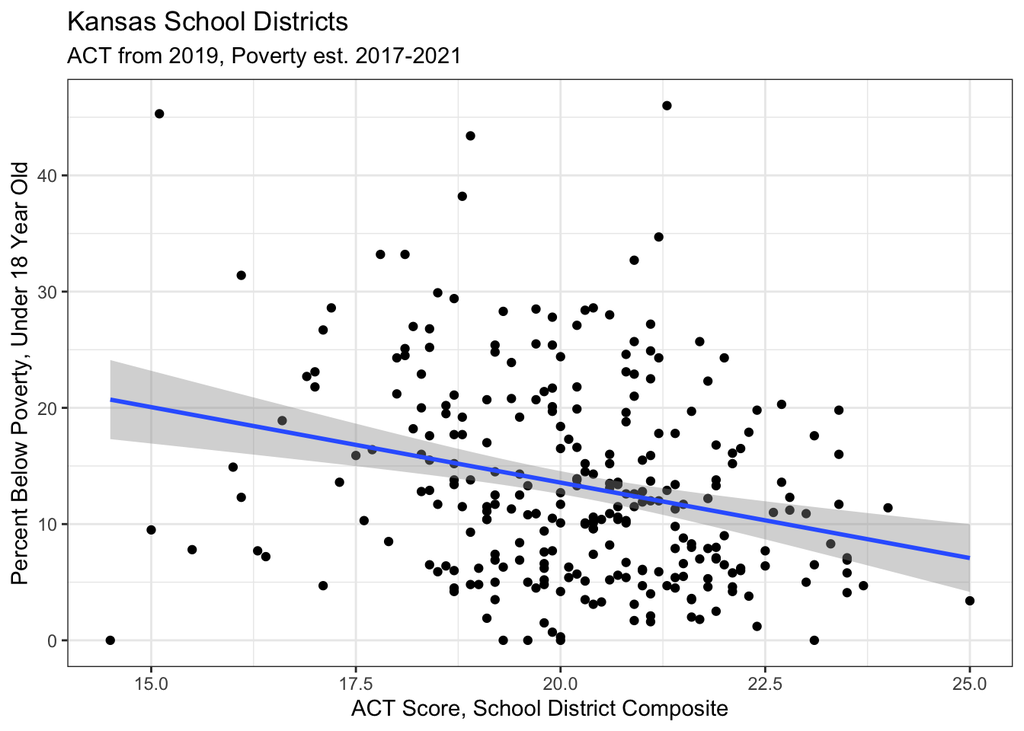

```r
plotACTpoverty <- acs_poverty_districts_scores |>
  ggplot(aes(x = ACT_Score, y = under18_below_pov)) +
  geom_point() +
  geom_smooth(method = lm) +
  theme_bw() +
  labs(
    x = "ACT Score, School District Composite",
    y = "Percent Below Poverty, Under 18 Year Old",
    title = "Kansas School Districts",
    subtitle = "ACT from 2019, Poverty est. 2017-2021"
  )

plotACTpoverty
```

Looked at the data table and 7 school districts did not have an ACT score data point (they are NA). Will need to drop.

## File for combining school district geo with other types of geos

Read original file downloaded from: https://nces.ed.gov/programs/edge/Geographic/RelationshipFiles

It contains all U.S. school districts (note I ended up using a district-to-zip code file but this one will be useful if we are given census tracts in the future, for library data)

```r
schooldist_geo_ori <- read_csv("grf19_lea_tract.csv")
```

Select columns:

LEAID = school district census ID

NAME_LEA19 = school district name (in 2019)

TRACT = census tract

```r
schooldist_geo <- schooldist_geo_ori |>
  select(LEAID, NAME_LEA19, TRACT)

# head(schooldist_geo)
```

## Table with school districts, poverty, and census tracts

Now, join the above table via LEAID which is identical to geo_id in the ACS poverty data table. Do a left join, ACS Kansas districts on the left, which means stuff that’s not in Kansas will drop out.

```r
acs_poverty_join_tracts <- acs_poverty_districts_scores |>
  left_join(schooldist_geo, by = c("geo_id" = "LEAID"))
```

This worked, but now I have more rows than school districts, because most districts have multiple census tracts. So there is a row for each tract, for each district.

BUT the Library data can’t be joined to this because Library data seems to contain the number of tracts (that is, count) rather than the census tract number – even though the documentation file says it is the census tract (so maybe this info is available from them? probably!). The “outlets” file has the same issue!! They probably have another data file that lists multiple rows for each library, one row per tract. In any case none of our Library files have proper tract ID, so if or until we obtain that, it seems it is best to use ZIP codes.

So use the district - zip code file, downloaded together with district - tract file; file name is grf19_lea_zcta5ce10.csv (exported from Excel)

## Table with school districts matched to zip codes

```r
schooldist_zip_ori <- read_csv("grf19_lea_zcta5ce10.csv")
```

There are zeroes for some zip codes but it is okay (this is stream-lined copy code file; I cut some trouble shooting stuff from this spot)

## Library Data File for 2019

```r
# read in data file as tibble object
library_2019_ori <- read_csv("PLS_FY19_AE_pud19i.csv")
```

First select the columns and filter for just Kansas; then join to the above data table.

Note, for KS, there are no overlapping service areas, so population of service area is same as the calculated unduplicated area (POPU_LSA = POPU_UND). Also, Masters vs Librarian - I think it is good to separate because just the “librarian” title is very vague, can be a wide range of expertise BUT that number probably includes the Masters librarians (yes it does). The following list does not render well in HTML:

LIBID = library ID number (so we can retrieve the row if needed)

ZIP = will use to join to acs_pov_tracts_districts_zip

POPU_LSA = population of library legal service area

CENTLIB = number of central libraries in service area

BRANLIB = number of branch libraries

BKMOB = number of bookmobiles

MASTER = number of FTE Master’s degree librarians

LIBRARIA = number of FTE with title of Librarian.

TOTSTAFF = total FTE

LOCGVT = $ from local gov’t (reflects local economic advantages)

STGVT = $ from state gov’t

TOTINCM = operating $ from all sources (including “other”)

STAFFEXP = cost of salaries plus benefits (there are var for each too)

TOTEXPCO = total spending on library materials (could be broken up)

TOTOPEXP = total spending on all expenses

CAP_REV = total capital revenue (could be broken down; look if big)

CAPITAL = total capital expenditures(could be broken down) BKVOL = print materials (books, gov’t documents)

BKVOL = Print materials (including books and government documents

EBOOK = electronic books and digital documents

AUDIO_PH = physical audio like CDs

AUDIO_DL = downloadable audio

VIDEO_PH = physical video

VIDEO_DL = downloadable video

HRS_OPEN = total service hours, all outlets

VISITS = total annual library visits

ELMATCIR = circulation of e materials

PHYSCIR = circulation of physical materials (not in 2015)

ELINFO = this is things like accessing online courses, NYTimes, etc (not in 2015)

TOTCOLL = all circulation (electronic, phyisical, and access elinfo) (TOTCIR in 2015)

TOTPRO = total library programs

KIDPRO = total children progs

YAPRO = total young adult progs

TOTATTEN = total audience, all progs

KIDATTEN = audience kid progs

YAATTEN = audience young adult progs

WEBVISIT = total visit library website (not in 2015)

I am folding the code ’cause it is long

```r
library_2019_KS_select <- library_2019_ori |>
  filter(STABR == "KS") |>
  select(
    LIBID,
    ZIP,
    POPU_LSA,
    MASTER,
    LIBRARIA,
    TOTSTAFF,
    LOCGVT,
    STGVT,
    TOTINCM,
    TOTEXPCO,
    TOTOPEXP,
    BKVOL,
    EBOOK,
    AUDIO_PH,
    VIDEO_PH,
    HRS_OPEN,
    VISITS,
    ELMATCIR,
    PHYSCIR,
    ELINFO,
    TOTCOLL,
    TOTPRO,
    KIDPRO,
    YAPRO,
    TOTATTEN,
    KIDATTEN,
    YAATTEN,
  )
```

Filtering for KS gives a # that is quite similar (somewhat more) than the number of “school districts”, ~286 vs 325 rows (329 in 2015).

Deleted some ori code from this spot because remade data set using Zip instead of tracts…

Looking through the columns of this easier-to-peruse set, we can easily eliminate the following columns because they will not be useful (I deleted from above code):

CENTLIB,BRANLIB,BKMOB (central, branch and bookmobile) because they are either mostly all “1” or “0” = rare and not helpful.

STAFFEXP because lots of libraries did not report how much they spent on compensation (or else it is not in this public file)

CAP_REV and CAPITAL because lots of “0” or high numbers; apparently this refers to putting up new buildings and should not be considered in a single year span (I thought it would be things like electricity and water and furniture and computers, etc but apparently not)

AUDIO_DL and VIDEO_DL = Digital audio and digital video in the libraries’ “collections” because they are same for most of the libraries; probably subscribe to same service, or Kansas State negotiated deals for the state.

WEBVISIT because too many libraries did not track this or did not provide it.

36 - 9 = 27 columns left.

## Files for characterizing library resources (funding source distro, and different years)

This is the stuff I made for Bakh; look at funding sources, and changes through time

```r
write_csv(library_2019_KS_select, "library_2019_KS_select.csv")

# There is already a copy in the R project folder so I commented out
```

Above is the file used for wrangling to generate our primary data set, but it is only library data. Not school districts, not poverty, not test scores, just libraries.

Make the same for other years.

For now just add 2015 and 2017, to our 2019 set. We have ACT scores only from 2015 and newer, so that’s one reason. And I’m rushing.

2015

```r
# read in data file as tibble object
library_2015_ori <- read_csv("PLS_FY2015_AE_pupld15a.csv")
```

2017

```r
# read in data file as tibble object
library_2017_ori <- read_csv("PLS_FY17_AE_pud17i.csv")
```

Make selections as for 2019 and confirm all columns are same so I can do the append. Do them separately so I don’t try to append before selections (the zillions of columns may not all match perfectly before selecting)

Yep that was smart because even our selections are not called the same.

for selecting variables, 2015 file does not have PHYSCIR

So remove that, and add in TOTCIR and KIDCIRCL

Well no let’s remove them for now. They also have imputation versions F_TOTCIR and F_KIDCIR and F_PHYSCIR.

There is also no ELINFO so delete that too.

Also no TOTCOLL

(so remove TOTCOLL ELINFO PHYSCIR from 2019 and 2017; note that 2017 does have these and all other original 2019 selections)

**Add in** FEDGVT, OTHINCM, which I did not have in our original selections.

```r
library_2015_KS_select <- library_2015_ori |>
  filter(STABR == "KS") |>
  select(
    LIBID,
    ZIP,
    POPU_LSA,
    MASTER,
    LIBRARIA,
    TOTSTAFF,
    LOCGVT,
    STGVT,
    FEDGVT,
    OTHINCM,
    TOTINCM,
    TOTEXPCO,
    TOTOPEXP,
    BKVOL,
    EBOOK,
    AUDIO_PH,
    VIDEO_PH,
    HRS_OPEN,
    VISITS,
    ELMATCIR,
    TOTPRO,
    KIDPRO,
    YAPRO,
    TOTATTEN,
    KIDATTEN,
    YAATTEN,
  ) |>
  mutate(YEAR = 2015)
```

repeat for 2017

```r
library_2017_KS_select <- library_2017_ori |>
  filter(STABR == "KS") |>
  select(
    LIBID,
    ZIP,
    POPU_LSA,
    MASTER,
    LIBRARIA,
    TOTSTAFF,
    LOCGVT,
    STGVT,
    FEDGVT,
    OTHINCM,
    TOTINCM,
    TOTEXPCO,
    TOTOPEXP,
    BKVOL,
    EBOOK,
    AUDIO_PH,
    VIDEO_PH,
    HRS_OPEN,
    VISITS,
    ELMATCIR,
    TOTPRO,
    KIDPRO,
    YAPRO,
    TOTATTEN,
    KIDATTEN,
    YAATTEN,
  ) |>
   mutate(YEAR = 2017)
```

And redo for 2019 so we have the same columns as 2015 2017 (remove TOTCOLL ELINFO PHYSCIR)

```r
library_2019_KS_select2 <- library_2019_ori |>
  filter(STABR == "KS") |>
  select(
    LIBID,
    ZIP,
    POPU_LSA,
    MASTER,
    LIBRARIA,
    TOTSTAFF,
    LOCGVT,
    STGVT,
    FEDGVT,
    OTHINCM,
    TOTINCM,
    TOTEXPCO,
    TOTOPEXP,
    BKVOL,
    EBOOK,
    AUDIO_PH,
    VIDEO_PH,
    HRS_OPEN,
    VISITS,
    ELMATCIR,
    TOTPRO,
    KIDPRO,
    YAPRO,
    TOTATTEN,
    KIDATTEN,
    YAATTEN,
  ) |>
   mutate(YEAR = 2019)
```

Now append

```r
lib_KS_selects_15_17 <- rbind(library_2015_KS_select, library_2017_KS_select)
```

```r
lib_KS_selects_15_17_19 <- rbind(lib_KS_selects_15_17, library_2019_KS_select2)
```

Normalize to population in service area

```r
# retrieve the column I need to divide by:
service_pop = lib_KS_selects_15_17_19$POPU_LSA

# Use lambda (anonymous) function to call selected col and
# divide the column by service_pop vector

lib_KS_selects_15_17_19_popadjust <- lib_KS_selects_15_17_19 |>
  mutate(
    across(
      .cols = c(
        LOCGVT,
        STGVT,
        FEDGVT,
        OTHINCM,
        TOTINCM,
        TOTEXPCO,
        TOTOPEXP,
        BKVOL,
        EBOOK,
        AUDIO_PH,
        VIDEO_PH,
        VISITS,
        ELMATCIR,
        TOTPRO,
        KIDPRO,
        YAPRO,
        TOTATTEN,
        KIDATTEN,
        YAATTEN
      ),
      .fns = \(x) x/service_pop
    )
  )
```

Write out file (this one is before normalizing)

```r
write_csv(lib_KS_selects_15_17_19, "lib_KS_selects_15_17_19.csv")

# There is already a copy in the R project folder so I commented out
```

This one is after adjusting resource to population per serivice area

```r
write_csv(lib_KS_selects_15_17_19_popadjust, "lib_KS_selects_15_17_19_popadjust.csv")

# There is already a copy in the R project folder so I commented out
```

I can use Census poverty data for 2017-2021 (my file is 5-year estimates) but I think it is good enough that I looked at that for 2019 no? So I just want to join school districts and test scores to the above data set.

## Adding ACT scores into single file for 2015 2017 2019

I can add ACT scores for 2015 and 2017 to my 2019 set. The more data the better.

Go up to heading “ACT test scores” (line 145 of this file) for explanations of steps; just repeating but more years filtered.

Well my original data set for KSDE was ACT scores for every year from 2015-2022.

That’s this tibble: ACT_2015_2022_ori

```r
ACT_2015_17_19 <- ACT_2015_2022_ori |>
  filter(
    `School Year` == 2015 | `School Year` == 2017 | `School Year` == 2019
  )
```

get just district composite data:

```r
ACT_2015_17_19_district <- ACT_2015_17_19 |>
  filter(`Bldg. No.` == 0) |>
  select(
    `Org. No.`,
    `Organization Name`,
    `District Composite`,
    `School Year`
  )
```

Rename `District Composite` to `ACT_Scores`

```r
ACT_2015_17_19_district <- ACT_2015_17_19_district |>
  rename(ACT_Score = `District Composite`)
```

fix district numbers to facilitate joining with other data

```r
ACT_2015_17_19_district_no <- ACT_2015_17_19_district |>
  separate_wider_position(
    cols = `Org. No.`,
    widths = c(toss = 2, district_no = 3)
  ) |>
  select(-toss)

# head(ACT_2015_17_19_district_no)
```

Change district to numeric to facilitate joins

```r
ACT_2015_17_19_district_no <- ACT_2015_17_19_district_no |>
  mutate(district_number = as.numeric(district_no)) |>
  na.omit() |>
  select(-district_no)

# the NA's were not districts but ks state total, became NA when convert to numeric
```

The above table may be useful for some types of analysis.

I need to reshape the data in order to join to ACS data (has districts and tracts and poverty data; need tracts so I can join to tract-zip data, and then join to Library-zip data)

Also, don’t really “lose data points” by doing this, because more rows now are not really more data points – more school districts would be more data points because I don’t expect test score outcomes to vary from year to year along with library resources (resources have long-term, slow effects) so it is okay to collapse to one row per district, and years are columns, another set of variables to consider

I need to have years as columns, and move ACT scores into those columns, so pivot wide

```r
ACT_2015_17_19_district_wide <- ACT_2015_17_19_district_no |>
  pivot_wider(
    names_from = "School Year",
    values_from = "ACT_Score"
  )

# head(ACT_2015_17_19_district_wide)
```

But if I want to match library data to the years then it does need the long form not the wide form.

Okay, join long form of school datat to census (tracts) and get zip codes and join to library. Then pivot wider like I did above, for chosen variables, to see how they change in the 5 year span (every odd year only).

Probably the best way to do it is, filter score data by year and join separately to each year of library data. Then append to form one data set. Pivot_wider only when I want to look at a particular variable comparing to different years. Because really for this type of data I do not expect scores to track closely the available resources year-by-year.

But before I join in the library data, I would really like to add other edu outcomes besides just ACT scores.

## EdFacts 2018-2019 school year

But EdFacts data is available as complete data set for US School districts; math and reading/language arts. I downloaded READING-Language Arts.

Each state establishes performance levels so unlike ACT, can’t really be compared between states.

```r
# read in data file as tibble object
edfacts_2019 <- read_csv("rla-achievement-lea-sy2018-19-wide.csv")
```

Read in data, filter for Kansas and look at these variables:

STNAM - filter KANSAS rows ST_LEAID - can get district number ALL_RLA00pctprof_1819 - Percentage of students who scored at or above proficient

(further broken down by race, gender, and so forth but won’t use)

```r
edfacts_2019_KS_sel_a <- edfacts_2019 |>
  filter(STNAM == "KANSAS") |>
  select(ST_LEAID, ALL_RLA00pctprof_1819) |> na.omit()

head(edfacts_2019_KS_sel_a)
```

```
# A tibble: 6 × 2
  ST_LEAID ALL_RLA00pctprof_1819
  <chr>    <chr>
1 KS-D0306 38
2 KS-D0400 42
3 KS-D0320 40
4 KS-D0323 52
5 KS-D0415 43
6 KS-D0237 54
```

Many of the scores are given as ranges, probably because different grade levels took the tests. I will use the dash in something like 43-56 as a delimiter and split in two columns and average.

First filter all rows that have a dash in the score column because I will do averaging of the two numbers and then recombine

```r
edfacts_2019_KS_sel_dash <- edfacts_2019_KS_sel_a |>
  filter(grepl('-', ALL_RLA00pctprof_1819))

head(edfacts_2019_KS_sel_dash)
```

```
# A tibble: 6 × 2
  ST_LEAID ALL_RLA00pctprof_1819
  <chr>    <chr>
1 KS-D0223 40-44
2 KS-D0275 30-39
3 KS-D0106 30-39
4 KS-D0108 30-34
5 KS-D0107 45-49
6 KS-D0110 35-39
```

Also get a table with the rows that have no dashes

```r
edfacts_2019_KS_sel_NOdash <- edfacts_2019_KS_sel_a |>
  filter(!grepl('-', ALL_RLA00pctprof_1819)) |>
  mutate(
    RLA_Scores = as.numeric(ALL_RLA00pctprof_1819)
  ) |>
  select(-ALL_RLA00pctprof_1819)
```

Split the dashes scores into two columns, make them numeric, then average them

```r
edfacts_2019_KS_sel_dash_split <- edfacts_2019_KS_sel_dash |>
  separate_wider_delim(
    cols = ALL_RLA00pctprof_1819,
    delim = "-",
    names = c("low", "high")
  ) |>
  mutate(
    high = as.numeric(high),
    low = as.numeric(low)
  )
```

```r
RLA_Scores <- (edfacts_2019_KS_sel_dash_split$low + edfacts_2019_KS_sel_dash_split$high)/2

edfacts_2019_KS_sel_dash_ave <- edfacts_2019_KS_sel_dash_split |>
  mutate(RLA_Scores = RLA_Scores) |>
  select(-c("low", "high"))
```

Now recombine the two parts of the dataset

```r
edfacts_2019_KS_sel_b <- rbind(edfacts_2019_KS_sel_dash_ave, edfacts_2019_KS_sel_NOdash)
```

Now fix district number so it is a simple number with no prefixes. Need to remove first 5 characters and keep last 3

```r
edfacts_2019_KS_sel <- edfacts_2019_KS_sel_b |>
  separate_wider_position(
    cols = ST_LEAID,
    widths = c(toss = 5, district_number = 3)
  ) |>
  select(-toss) |>
  mutate(district_number = as.numeric(district_number))

# head(edfacts_2019_KS_sel)
```

There are 286 districts as expected. (ACT is ~295 but includes some religious/private etc)

Just do 2019 ACT scores, not the other two years I have in my subset

```r
district_ACT_2019 <- ACT_2015_17_19_district_no |>
  filter(`School Year` == 2019)
```

```r
district_ACT_RLA_2019 <- edfacts_2019_KS_sel |>
  left_join(district_ACT_2019, by = "district_number") |> na.omit()

# seven districts were lost, probably the private/religious schools; 279 left

# head(district_ACT_RLA_2019)
```

Now I have both Reading/Language Arts score and ACT score for all “normal” KS districts

Join it with census data so I can get tracts which I can then (for now at least) join with zip codes, and then join to library.

## Joining School test data with ACS census data

```r
acs_poverty_distr_scores_tracks <- acs_poverty_districts_d |>
  left_join(
    district_ACT_RLA_2019,
    by = "district_number"
  ) |>
  mutate(geo_id_dist = as.numeric(geo_id)) |>
  select(-geo_id) |> na.omit()

# again it went from 286 to 279 districts after remove NA
```

The above table will likely be useful for further analyses. Remember geo_id is a district ID not tract ID. Unlike in the prior iteration above when I made my first Group1 dataset (as well as the one with means for library data), I am not going join in tracts because I think the district-zip file (schooldist_zip_ori) should work; it just has zeroes for geo regions without zip is my guess, but those districts also have rows in the table that do have some zip codes.

I will also select the zip code column this time

```r
schooldist_zip_leaID <- schooldist_zip_ori |>
  select(LEAID, NAME_LEA19, ZCTA5CE10) |>
  mutate(ZIP = as.numeric(ZCTA5CE10)) |>
  mutate(geo_id_dist = as.numeric(LEAID)) |>
  select(-c("ZCTA5CE10", "LEAID")) |>
  filter(ZIP > 0)

# head(schooldist_zip_leaID)
```

```r
acs_pov_distr_scores_tracks_zips <- acs_poverty_distr_scores_tracks |>
  left_join(schooldist_zip_leaID, by = "geo_id_dist")

acs_pov_distr_scores_tracks_zips
```

```
# A tibble: 1,971 × 13
   district_name           district_number total_pop under18_pop total_below_pov
   <chr>                             <dbl>     <dbl>       <dbl>           <dbl>
 1 "Southeast of Saline U…             306      2887         691             4.7
 2 "Southeast of Saline U…             306      2887         691             4.7
 3 "Southeast of Saline U…             306      2887         691             4.7
 4 "Southeast of Saline U…             306      2887         691             4.7
 5 "Southeast of Saline U…             306      2887         691             4.7
 6 "Southeast of Saline U…             306      2887         691             4.7
 7 "Smoky Valley Unified …             400      5522        1410            13.8
 8 "Smoky Valley Unified …             400      5522        1410            13.8
 9 "Smoky Valley Unified …             400      5522        1410            13.8
10 "Smoky Valley Unified …             400      5522        1410            13.8
# ℹ 1,961 more rows
# ℹ 8 more variables: under18_below_pov <dbl>, RLA_Scores <dbl>,
#   `Organization Name` <chr>, ACT_Score <dbl>, `School Year` <dbl>,
#   geo_id_dist <dbl>, NAME_LEA19 <chr>, ZIP <dbl>
```

See if I lost any districts by doing this

```r
how_many_districts <- acs_pov_distr_scores_tracks_zips |>
  summarize(
    number_unique_districts = n_distinct(district_number),
    number_samples = n()
  ) |> print()
```

```
# A tibble: 1 × 2
  number_unique_districts number_samples
                    <int>          <int>
1                     279           1971
```

All looks good. Now do the join to the Libraries data set. Do just 2019 library data for now; do the table I made earlier with the 3 extra variables that I removed in the more recent version in order to append 2015 lib data. (remember this one does not have Federal and Other contribution, only state, local, total)

Think about this join. I do not want to lose districts. Remember there are lots of duplicated zip codes so the join may not be straight forward. Well let’s see how many:

```r
how_many_zips <- acs_pov_distr_scores_tracks_zips |>
  summarize(
    number_unique_zipcodes = n_distinct(ZIP),
    number_samples = n()
  ) |> print()
```

```
# A tibble: 1 × 2
  number_unique_zipcodes number_samples
                   <int>          <int>
1                    700           1971
```

So quite a lot. Remember tho a lot of the zips will fall out because there are only 325 libraries (very unlikely that there are duplicate zip codes in the library file). So any zip that does not have a matching library zip is lost, but each school district has numerous zips

Join attempt did not work; need to convert library zip to numeric.

```r
library_2019_KS_select <- library_2019_KS_select |>
  mutate(ZIP = as.numeric(ZIP))
```

And normalize for population for service area

```r
# retrieve the column I need to divide by:
service_pop = library_2019_KS_select$POPU_LSA

# Use lambda (anonymous) function to call selected col and
# divide the column by service_pop vector

library_2019_popadjust_a <- library_2019_KS_select |>
  mutate(
    across(
      .cols = c(
        LOCGVT,
        STGVT,
        TOTINCM,
        TOTEXPCO,
        TOTOPEXP,
        BKVOL,
        EBOOK,
        AUDIO_PH,
        VIDEO_PH,
        VISITS,
        ELMATCIR,
        PHYSCIR,
        ELINFO,
        TOTCOLL,
        TOTPRO,
        KIDPRO,
        YAPRO,
        TOTATTEN,
        KIDATTEN,
        YAATTEN
      ),
      .fns = \(x) x/service_pop
    )
  )
```

```r
Group1_dataset2_a <-acs_pov_distr_scores_tracks_zips |>
  left_join(library_2019_popadjust_a, by = "ZIP") |> na.omit()

# 1971 rows so nothing dropped out from ACS set until I did NA removal, now 1100
# So as expected a lot of zip codes did not have libraries and those are gone.
```

See if any districts lost:

```r
how_many_districts <- Group1_dataset2_a |>
  summarize(
    number_unique_districts = n_distinct(district_number),
    number_samples = n()
  ) |> print()
```

```
# A tibble: 1 × 2
  number_unique_districts number_samples
                    <int>          <int>
1                     276           1100
```

Okay, now I need to average the library resources for each district. Do like last time (did not need the na.rm but I just copy pasted)

```r
Group1_dataset2_means <- Group1_dataset2_a |>
  summarize(
    mean_LOCGVT = mean(LOCGVT, na.rm = TRUE),
    mean_STGVT = mean(STGVT, na.rm = TRUE),
    mean_TOTINCM = mean(TOTINCM, na.rm = TRUE),
    mean_TOTEXPCO = mean(TOTEXPCO, na.rm = TRUE),
    mean_TOTOPEXP = mean(TOTOPEXP, na.rm = TRUE),
    mean_BKVOL = mean(BKVOL, na.rm = TRUE),
    mean_EBOOK = mean(EBOOK, na.rm = TRUE),
    mean_AUDIO_PH = mean(AUDIO_PH, na.rm = TRUE),
    mean_VIDEO_PH = mean(VIDEO_PH, na.rm = TRUE),
    mean_VISITS = mean(VISITS, na.rm = TRUE),
    mean_ELMATCIR = mean(ELMATCIR, na.rm = TRUE),
    mean_PHYSCIR = mean(PHYSCIR, na.rm = TRUE),
    mean_ELINFO = mean(ELINFO, na.rm = TRUE),
    mean_TOTCOLL = mean(TOTCOLL, na.rm = TRUE),
    mean_TOTPRO = mean(TOTPRO, na.rm = TRUE),
    mean_KIDPRO = mean(KIDPRO, na.rm = TRUE),
    mean_YAPRO = mean(YAPRO, na.rm = TRUE),
    mean_TOTATTEN = mean(TOTATTEN, na.rm = TRUE),
    mean_KIDATTEN = mean(KIDATTEN, na.rm = TRUE),
    mean_YAATTEN = mean(YAATTEN, na.rm = TRUE),
    mean_MASTER = mean(MASTER, na.rm = TRUE),
    mean_LIBRARIA = mean(LIBRARIA, na.rm = TRUE),
    mean_TOTSTAFF = mean(TOTSTAFF, na.rm = TRUE),
    mean_HRS_OPEN = mean(HRS_OPEN, na.rm = TRUE),
    total_below_pov = mean(total_below_pov),
    under18_below_pov = mean(under18_below_pov),
    ACT_Score = mean(ACT_Score),
    RLA_Scores = mean(RLA_Scores),
    `School Year` = mean(`School Year`),
    .by = district_number
  )

# note that the final 4 library variables were not normalized for population count because it made less sense (especially hours open)

# Note that data columns from ACS-school data set are all the same data for a school
# district so it would not have had to be averaged if I had bee able to do the averaging # before adding in scores and poverty and whatnot.
```

So now this should be collapsed back down to district number

```r
how_many_districts <- Group1_dataset2_means |>
  summarize(
    number_unique_districts = n_distinct(district_number),
    number_samples = n()
  ) |> print()
```

```
# A tibble: 1 × 2
  number_unique_districts number_samples
                    <int>          <int>
1                     276            276
```

Yes. Make the file!

First I need to fix `School Year` variable because it causes problems to have a space in some python work

```r
Group1_dataset2_means <- Group1_dataset2_means |>
  mutate(School_Year = `School Year`) |>
  select(-`School Year`)
```

```r
write_csv(Group1_dataset2_means, "Group1_dataset2_means.csv")

# There is already a copy in the R project folder so I commented out
```

## Histograms to show distro of most promising variables

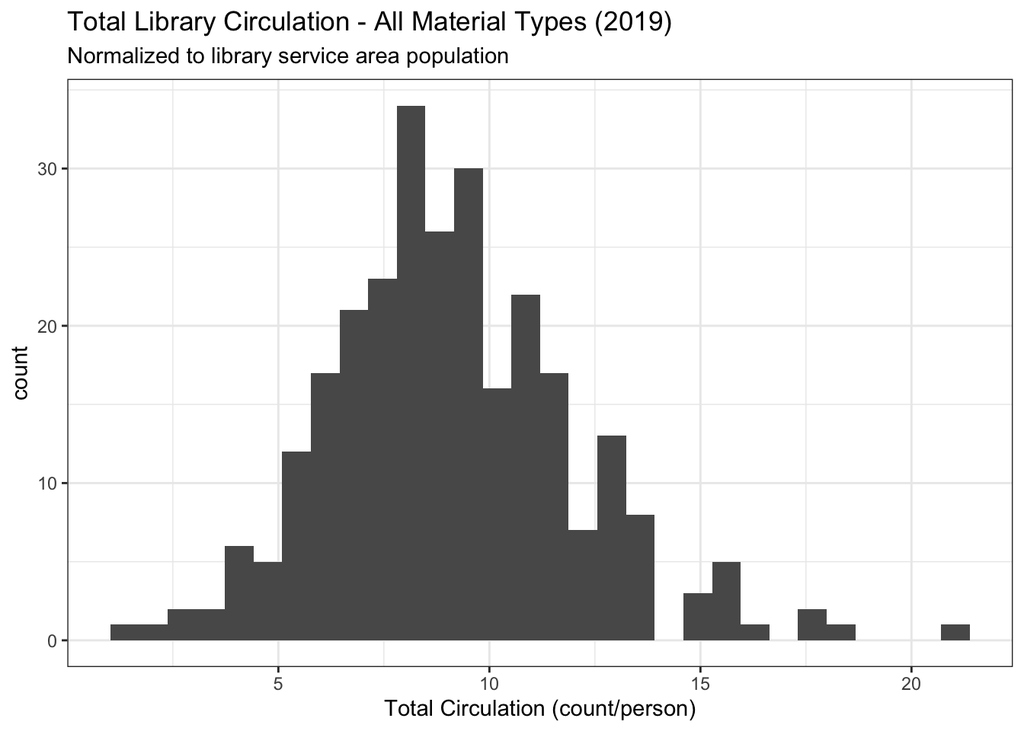

```r
plot_TOTCOLL <- Group1_dataset2_means |>
  ggplot(aes(x = mean_TOTCOLL)) +
  geom_histogram()+
  theme_bw() +
  labs(
  x = "Total Circulation (count/person)",
  title = "Total Library Circulation - All Material Types (2019)",
  subtitle = "Normalized to library service area population"
  )

plot_TOTCOLL
```

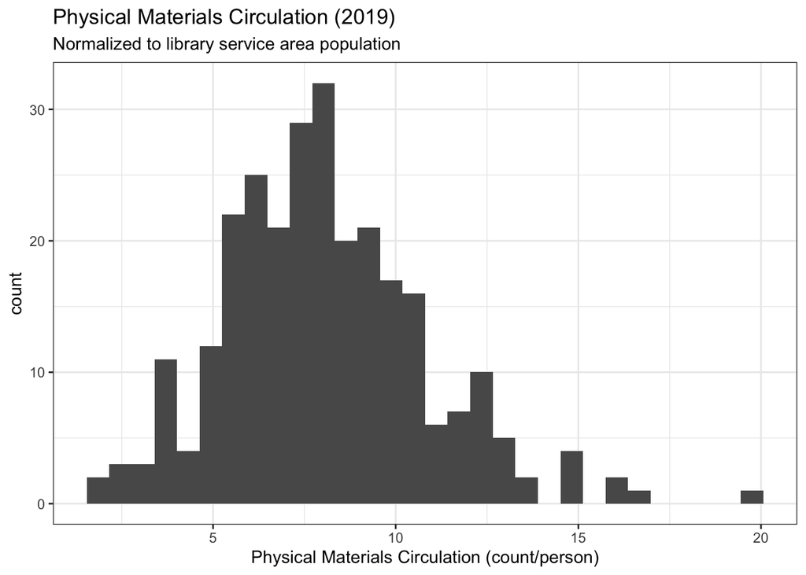

```r
plot_PHYSCIR <- Group1_dataset2_means |>
  ggplot(aes(x = mean_PHYSCIR)) +
  geom_histogram()+
  theme_bw() +
  labs(
  x = "Physical Materials Circulation (count/person)",
  title = "Physical Materials Circulation (2019)",
  subtitle = "Normalized to library service area population"
  )

plot_PHYSCIR
```

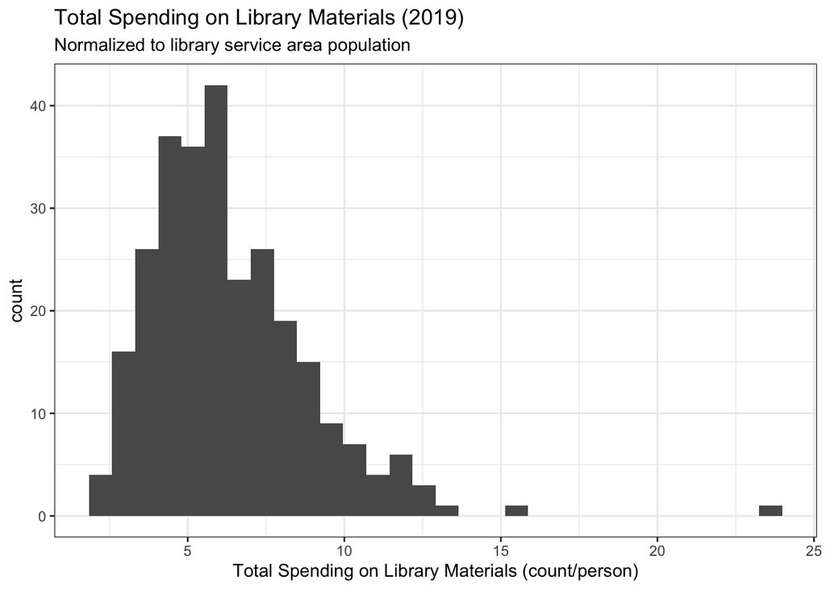

```r
plot_TOTEXPCO <- Group1_dataset2_means |>
  ggplot(aes(x = mean_TOTEXPCO)) +
  geom_histogram()+
  theme_bw() +
  labs(
  x = "Total Spending on Library Materials (count/person)",
  title = "Total Spending on Library Materials (2019)",
  subtitle = "Normalized to library service area population"
  )

plot_TOTEXPCO
```

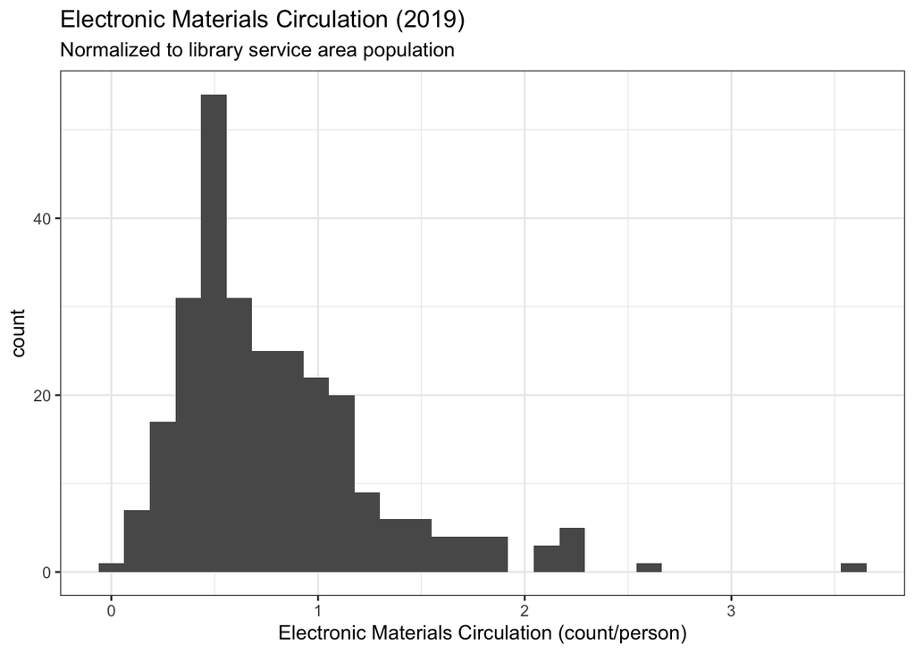

```r
plot_ELMATCIR <- Group1_dataset2_means |>
  ggplot(aes(x = mean_ELMATCIR)) +
  geom_histogram()+
  theme_bw() +
  labs(
  x = "Electronic Materials Circulation (count/person)",
  title = "Electronic Materials Circulation (2019)",
  subtitle = "Normalized to library service area population"
  )

plot_ELMATCIR
```

## Correlation analysis with fixed data set

Okay, redo the correlation analysis. I am CUTTING pasting (don’t need the old version)

First redo the data where I concluded that we don’t have to worry about poverty; does that still hold with the much better quality data set:

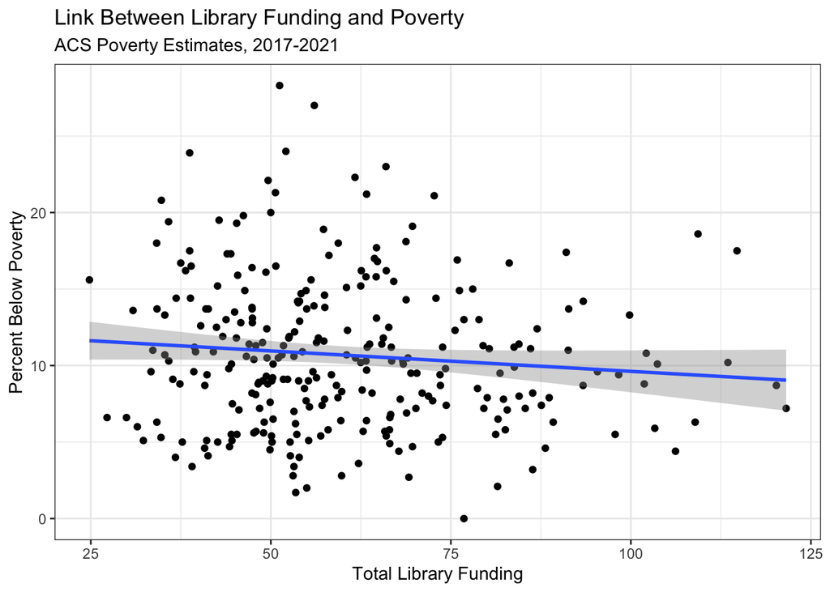

```r
plotPovertyResources2 <- Group1_dataset2_means |>
  ggplot(aes(x = mean_TOTINCM, y = total_below_pov)) +
  geom_point() +
  geom_smooth(method = lm) +
  theme_bw() +
  labs(
    x = "Total Library Funding",
    y = "Percent Below Poverty",
    title = "Link Between Library Funding and Poverty",
    subtitle = "ACS Poverty Estimates, 2017-2021"
  )

plotPovertyResources2
```

Petty similar to what it was before, so conclusions not changed; it seems we don’t have to worry that it is just money and not library resources that is the potential link to test scores when looking at library resources. Swap out from Report since this data set was made better; above results are more accurate than slide/report figure.

Now repeat the Pearson’s correlation tests for our variables of itnerest to see which are most promising (I deleted tests from the bad data set)

## Pearson’s Correlation with RLA scores and Library varialbels

```r
cor_LOCGVT <- cor.test(
  Group1_dataset2_means$mean_LOCGVT,
  Group1_dataset2_means$RLA_Scores,
  method = "pearson"
  )

cor_LOCGVT
```

```
    Pearson's product-moment correlation

data:  Group1_dataset2_means$mean_LOCGVT and Group1_dataset2_means$RLA_Scores
t = -1.363, df = 274, p-value = 0.174
alternative hypothesis: true correlation is not equal to 0
95 percent confidence interval:
 -0.19821106  0.03635903
sample estimates:
        cor
-0.08206239
```

```r
cor_STGVT <- cor.test(
  Group1_dataset2_means$mean_STGVT,
  Group1_dataset2_means$RLA_Scores,
  method = "pearson"
  )

cor_STGVT
```

```
    Pearson's product-moment correlation

data:  Group1_dataset2_means$mean_STGVT and Group1_dataset2_means$RLA_Scores
t = 0.90103, df = 274, p-value = 0.3684
alternative hypothesis: true correlation is not equal to 0
95 percent confidence interval:
 -0.06412794  0.17132244
sample estimates:
       cor
0.05435274
```

```r
cor_TOTINCM <- cor.test(
  Group1_dataset2_means$mean_TOTINCM,
  Group1_dataset2_means$RLA_Scores,
  method = "pearson"
  )

cor_TOTINCM
```

```
    Pearson's product-moment correlation

data:  Group1_dataset2_means$mean_TOTINCM and Group1_dataset2_means$RLA_Scores
t = -0.71588, df = 274, p-value = 0.4747
alternative hypothesis: true correlation is not equal to 0
95 percent confidence interval:
 -0.16045784  0.07524573
sample estimates:
        cor
-0.04320727
```

```r
cor_TOTEXPCO <- cor.test(
  Group1_dataset2_means$mean_TOTEXPCO,
  Group1_dataset2_means$RLA_Scores,
  method = "pearson"
  )

cor_TOTEXPCO
```

```
    Pearson's product-moment correlation

data:  Group1_dataset2_means$mean_TOTEXPCO and Group1_dataset2_means$RLA_Scores
t = 1.3066, df = 274, p-value = 0.1924
alternative hypothesis: true correlation is not equal to 0
95 percent confidence interval:
 -0.03974888  0.19494748
sample estimates:
       cor
0.07868956
```

```r
cor_TOTOPEXP <- cor.test(
  Group1_dataset2_means$mean_TOTOPEXP,
  Group1_dataset2_means$RLA_Scores,
  method = "pearson"
  )

cor_TOTOPEXP
```

```
    Pearson's product-moment correlation

data:  Group1_dataset2_means$mean_TOTOPEXP and Group1_dataset2_means$RLA_Scores
t = -0.85233, df = 274, p-value = 0.3948
alternative hypothesis: true correlation is not equal to 0
95 percent confidence interval:
 -0.16846917  0.06705337
sample estimates:
        cor
-0.05142289
```

```r
cor_BKVOL <- cor.test(
  Group1_dataset2_means$mean_BKVOL,
  Group1_dataset2_means$RLA_Scores,
  method = "pearson"
  )

cor_BKVOL
```

```
    Pearson's product-moment correlation

data:  Group1_dataset2_means$mean_BKVOL and Group1_dataset2_means$RLA_Scores
t = 0.95208, df = 274, p-value = 0.3419
alternative hypothesis: true correlation is not equal to 0
95 percent confidence interval:
 -0.06106089  0.17430959
sample estimates:
       cor
0.05742223
```

```r
cor_EBOOK <- cor.test(
  Group1_dataset2_means$mean_EBOOK,
  Group1_dataset2_means$RLA_Scores,
  method = "pearson"
  )

cor_EBOOK
```

```
    Pearson's product-moment correlation

data:  Group1_dataset2_means$mean_EBOOK and Group1_dataset2_means$RLA_Scores
t = 1.2628, df = 274, p-value = 0.2077
alternative hypothesis: true correlation is not equal to 0
95 percent confidence interval:
 -0.04238063  0.19241017
sample estimates:
       cor
0.07606915
```

```r
cor_AUDIO_PH <- cor.test(
  Group1_dataset2_means$mean_AUDIO_PH,
  Group1_dataset2_means$RLA_Scores,
  method = "pearson"
  )

cor_AUDIO_PH
```

```
    Pearson's product-moment correlation

data:  Group1_dataset2_means$mean_AUDIO_PH and Group1_dataset2_means$RLA_Scores
t = -1.3831, df = 274, p-value = 0.1678
alternative hypothesis: true correlation is not equal to 0
95 percent confidence interval:
 -0.1993755  0.0351482
sample estimates:
        cor
-0.08326649
```

```r
cor_VIDEO_PH <- cor.test(
  Group1_dataset2_means$mean_VIDEO_PH,
  Group1_dataset2_means$RLA_Scores,
  method = "pearson"
  )

cor_VIDEO_PH
```

```
    Pearson's product-moment correlation

data:  Group1_dataset2_means$mean_VIDEO_PH and Group1_dataset2_means$RLA_Scores
t = 1.3174, df = 274, p-value = 0.1888
alternative hypothesis: true correlation is not equal to 0
95 percent confidence interval:
 -0.03909753  0.19557497
sample estimates:
       cor
0.07933785
```

```r
cor_HRS_OPEN <- cor.test(
  Group1_dataset2_means$mean_HRS_OPEN,
  Group1_dataset2_means$RLA_Scores,
  method = "pearson"
  )

cor_HRS_OPEN
```

```
    Pearson's product-moment correlation

data:  Group1_dataset2_means$mean_HRS_OPEN and Group1_dataset2_means$RLA_Scores
t = -0.64084, df = 274, p-value = 0.5222
alternative hypothesis: true correlation is not equal to 0
95 percent confidence interval:
 -0.15604204  0.07974776
sample estimates:
        cor
-0.03868563
```

```r
cor_VISITS <- cor.test(
  Group1_dataset2_means$mean_VISITS,
  Group1_dataset2_means$RLA_Scores,
  method = "pearson"
  )

cor_VISITS
```

```
    Pearson's product-moment correlation

data:  Group1_dataset2_means$mean_VISITS and Group1_dataset2_means$RLA_Scores
t = -0.34737, df = 274, p-value = 0.7286
alternative hypothesis: true correlation is not equal to 0
95 percent confidence interval:
 -0.13870649  0.09732929
sample estimates:
        cor
-0.02098095
```

```r
cor_ELMATCIR <- cor.test(
  Group1_dataset2_means$mean_ELMATCIR,
  Group1_dataset2_means$RLA_Scores,
  method = "pearson"
  )

cor_ELMATCIR
```

```
    Pearson's product-moment correlation

data:  Group1_dataset2_means$mean_ELMATCIR and Group1_dataset2_means$RLA_Scores
t = 0.67949, df = 274, p-value = 0.4974
alternative hypothesis: true correlation is not equal to 0
95 percent confidence interval:
 -0.07742917  0.15831740
sample estimates:
       cor
0.04101493
```

```r
cor_PHYSCIR <- cor.test(
  Group1_dataset2_means$mean_PHYSCIR,
  Group1_dataset2_means$RLA_Scores,
  method = "pearson"
  )

cor_PHYSCIR
```

```
    Pearson's product-moment correlation

data:  Group1_dataset2_means$mean_PHYSCIR and Group1_dataset2_means$RLA_Scores
t = 2.3438, df = 274, p-value = 0.0198
alternative hypothesis: true correlation is not equal to 0
95 percent confidence interval:
 0.0224986 0.2540591
sample estimates:
      cor
0.1401953
```

```r
cor_ELINFO <- cor.test(
  Group1_dataset2_means$mean_ELINFO,
  Group1_dataset2_means$RLA_Scores,
  method = "pearson"
  )

cor_ELINFO
```

```
    Pearson's product-moment correlation

data:  Group1_dataset2_means$mean_ELINFO and Group1_dataset2_means$RLA_Scores
t = 0.23445, df = 274, p-value = 0.8148
alternative hypothesis: true correlation is not equal to 0
95 percent confidence interval:
 -0.1040810  0.1320106
sample estimates:
       cor
0.01416219
```

```r
cor_TOTCOLL <- cor.test(
  Group1_dataset2_means$mean_TOTCOLL,
  Group1_dataset2_means$RLA_Scores,
  method = "pearson"
  )

cor_TOTCOLL
```

```
    Pearson's product-moment correlation

data:  Group1_dataset2_means$mean_TOTCOLL and Group1_dataset2_means$RLA_Scores
t = 2.3635, df = 274, p-value = 0.0188
alternative hypothesis: true correlation is not equal to 0
95 percent confidence interval:
 0.02367962 0.25516414
sample estimates:
      cor
0.1413536
```

```r
cor_TOTPRO <- cor.test(
  Group1_dataset2_means$mean_TOTPRO,
  Group1_dataset2_means$RLA_Scores,
  method = "pearson"
  )

cor_TOTPRO
```

```
    Pearson's product-moment correlation

data:  Group1_dataset2_means$mean_TOTPRO and Group1_dataset2_means$RLA_Scores
t = -0.57865, df = 274, p-value = 0.5633
alternative hypothesis: true correlation is not equal to 0
95 percent confidence interval:
 -0.15237677  0.08347731
sample estimates:
        cor
-0.03493616
```

```r
cor_KIDPRO <- cor.test(
  Group1_dataset2_means$mean_KIDPRO,
  Group1_dataset2_means$RLA_Scores,
  method = "pearson"
  )

cor_KIDPRO
```

```
    Pearson's product-moment correlation

data:  Group1_dataset2_means$mean_KIDPRO and Group1_dataset2_means$RLA_Scores
t = -0.73197, df = 274, p-value = 0.4648
alternative hypothesis: true correlation is not equal to 0
95 percent confidence interval:
 -0.1614042  0.0742796
sample estimates:
        cor
-0.04417697
```

```r
cor_YAPRO <- cor.test(
  Group1_dataset2_means$mean_YAPRO,
  Group1_dataset2_means$RLA_Scores,
  method = "pearson"
  )

cor_YAPRO
```

```
    Pearson's product-moment correlation

data:  Group1_dataset2_means$mean_YAPRO and Group1_dataset2_means$RLA_Scores
t = -0.85434, df = 274, p-value = 0.3937
alternative hypothesis: true correlation is not equal to 0
95 percent confidence interval:
 -0.16858711  0.06693253
sample estimates:
        cor
-0.05154395
```

```r
cor_TOTATTEN <- cor.test(
  Group1_dataset2_means$mean_TOTATTEN,
  Group1_dataset2_means$RLA_Scores,
  method = "pearson"
  )

cor_TOTATTEN
```

```
    Pearson's product-moment correlation

data:  Group1_dataset2_means$mean_TOTATTEN and Group1_dataset2_means$RLA_Scores
t = -0.74876, df = 274, p-value = 0.4546
alternative hypothesis: true correlation is not equal to 0
95 percent confidence interval:
 -0.16239073  0.07327207
sample estimates:
      cor
-0.045188
```

```r
cor_KIDATTEN <- cor.test(
  Group1_dataset2_means$mean_KIDATTEN,
  Group1_dataset2_means$RLA_Scores,
  method = "pearson"
  )

cor_KIDATTEN
```

```
    Pearson's product-moment correlation

data:  Group1_dataset2_means$mean_KIDATTEN and Group1_dataset2_means$RLA_Scores
t = -0.8422, df = 274, p-value = 0.4004
alternative hypothesis: true correlation is not equal to 0
95 percent confidence interval:
 -0.16787552  0.06766153
sample estimates:
        cor
-0.05081355
```

```r
cor_YAATTEN <- cor.test(
  Group1_dataset2_means$mean_YAATTEN,
  Group1_dataset2_means$RLA_Scores,
  method = "pearson"
  )

cor_YAATTEN
```

```
    Pearson's product-moment correlation

data:  Group1_dataset2_means$mean_YAATTEN and Group1_dataset2_means$RLA_Scores
t = -0.74884, df = 274, p-value = 0.4546
alternative hypothesis: true correlation is not equal to 0
95 percent confidence interval:
 -0.1623953  0.0732674
sample estimates:
        cor
-0.04519268
```

# Pearson’s Correlation with ACT scores and Library resources

```r
cor_LOCGVT <- cor.test(
  Group1_dataset2_means$mean_LOCGVT,
  Group1_dataset2_means$ACT_Score,
  method = "pearson"
  )

cor_LOCGVT
```

```
    Pearson's product-moment correlation

data:  Group1_dataset2_means$mean_LOCGVT and Group1_dataset2_means$ACT_Score
t = -0.93652, df = 274, p-value = 0.3498
alternative hypothesis: true correlation is not equal to 0
95 percent confidence interval:
 -0.17339958  0.06199571
sample estimates:
       cor
-0.0564869
```

```r
cor_STGVT <- cor.test(
  Group1_dataset2_means$mean_STGVT,
  Group1_dataset2_means$ACT_Score,
  method = "pearson"
  )

cor_STGVT
```

```
    Pearson's product-moment correlation

data:  Group1_dataset2_means$mean_STGVT and Group1_dataset2_means$ACT_Score
t = 1.2874, df = 274, p-value = 0.199
alternative hypothesis: true correlation is not equal to 0
95 percent confidence interval:
 -0.04090306  0.19383510
sample estimates:
       cor
0.07754055
```

```r
cor_TOTINCM <- cor.test(
  Group1_dataset2_means$mean_TOTINCM,
  Group1_dataset2_means$ACT_Score,
  method = "pearson"
  )

cor_TOTINCM
```

```
    Pearson's product-moment correlation

data:  Group1_dataset2_means$mean_TOTINCM and Group1_dataset2_means$ACT_Score
t = -0.91614, df = 274, p-value = 0.3604
alternative hypothesis: true correlation is not equal to 0
95 percent confidence interval:
 -0.1722072  0.0632200
sample estimates:
        cor
-0.05526163
```

```r
cor_TOTEXPCO <- cor.test(
  Group1_dataset2_means$mean_TOTEXPCO,
  Group1_dataset2_means$ACT_Score,
  method = "pearson"
  )

cor_TOTEXPCO
```

```
    Pearson's product-moment correlation

data:  Group1_dataset2_means$mean_TOTEXPCO and Group1_dataset2_means$ACT_Score
t = 1.5931, df = 274, p-value = 0.1123
alternative hypothesis: true correlation is not equal to 0
95 percent confidence interval:
 -0.02252317  0.21147783
sample estimates:
       cor
0.09580074
```

```r
cor_TOTOPEXP <- cor.test(
  Group1_dataset2_means$mean_TOTOPEXP,
  Group1_dataset2_means$ACT_Score,
  method = "pearson"
  )

cor_TOTOPEXP
```

```
    Pearson's product-moment correlation

data:  Group1_dataset2_means$mean_TOTOPEXP and Group1_dataset2_means$ACT_Score
t = -1.1215, df = 274, p-value = 0.2631
alternative hypothesis: true correlation is not equal to 0
95 percent confidence interval:
 -0.18419647  0.05087778
sample estimates:
        cor
-0.06759743
```

```r
cor_BKVOL <- cor.test(
  Group1_dataset2_means$mean_BKVOL,
  Group1_dataset2_means$ACT_Score,
  method = "pearson"
  )

cor_BKVOL
```

```
    Pearson's product-moment correlation

data:  Group1_dataset2_means$mean_BKVOL and Group1_dataset2_means$ACT_Score
t = -1.8747, df = 274, p-value = 0.0619
alternative hypothesis: true correlation is not equal to 0
95 percent confidence interval:
 -0.227578537  0.005610524
sample estimates:
       cor
-0.1125332
```

```r
cor_EBOOK <- cor.test(
  Group1_dataset2_means$mean_EBOOK,
  Group1_dataset2_means$ACT_Score,
  method = "pearson"
  )

cor_EBOOK
```

```
    Pearson's product-moment correlation

data:  Group1_dataset2_means$mean_EBOOK and Group1_dataset2_means$ACT_Score
t = 0.93225, df = 274, p-value = 0.352
alternative hypothesis: true correlation is not equal to 0
95 percent confidence interval:
 -0.06225221  0.17314982
sample estimates:
       cor
0.05623023
```

```r
cor_AUDIO_PH <- cor.test(
  Group1_dataset2_means$mean_AUDIO_PH,
  Group1_dataset2_means$ACT_Score,
  method = "pearson"
  )

cor_AUDIO_PH
```

```
    Pearson's product-moment correlation

data:  Group1_dataset2_means$mean_AUDIO_PH and Group1_dataset2_means$ACT_Score
t = -3.3243, df = 274, p-value = 0.001007
alternative hypothesis: true correlation is not equal to 0
95 percent confidence interval:
 -0.30781181 -0.08070564
sample estimates:
       cor
-0.1968986
```

```r
cor_VIDEO_PH <- cor.test(
  Group1_dataset2_means$mean_VIDEO_PH,
  Group1_dataset2_means$ACT_Score,
  method = "pearson"
  )

cor_VIDEO_PH
```

```
    Pearson's product-moment correlation

data:  Group1_dataset2_means$mean_VIDEO_PH and Group1_dataset2_means$ACT_Score
t = -0.63258, df = 274, p-value = 0.5275
alternative hypothesis: true correlation is not equal to 0
95 percent confidence interval:
 -0.15555528  0.08024344
sample estimates:
       cor
-0.0381875
```

```r
cor_HRS_OPEN <- cor.test(
  Group1_dataset2_means$mean_HRS_OPEN,
  Group1_dataset2_means$ACT_Score,
  method = "pearson"
  )

cor_HRS_OPEN
```

```
    Pearson's product-moment correlation

data:  Group1_dataset2_means$mean_HRS_OPEN and Group1_dataset2_means$ACT_Score
t = 0.98626, df = 274, p-value = 0.3249
alternative hypothesis: true correlation is not equal to 0
95 percent confidence interval:
 -0.05900668  0.17630787
sample estimates:
       cor
0.05947683
```

```r
cor_VISITS <- cor.test(
  Group1_dataset2_means$mean_VISITS,
  Group1_dataset2_means$ACT_Score,
  method = "pearson"
  )

cor_VISITS
```

```
    Pearson's product-moment correlation

data:  Group1_dataset2_means$mean_VISITS and Group1_dataset2_means$ACT_Score
t = -3.0446, df = 274, p-value = 0.002557
alternative hypothesis: true correlation is not equal to 0
95 percent confidence interval:
 -0.29271220 -0.06419681
sample estimates:
       cor
-0.1808948
```

```r
cor_ELMATCIR <- cor.test(
  Group1_dataset2_means$mean_ELMATCIR,
  Group1_dataset2_means$ACT_Score,
  method = "pearson"
  )

cor_ELMATCIR
```

```
    Pearson's product-moment correlation

data:  Group1_dataset2_means$mean_ELMATCIR and Group1_dataset2_means$ACT_Score
t = 2.36, df = 274, p-value = 0.01898
alternative hypothesis: true correlation is not equal to 0
95 percent confidence interval:
 0.0234648 0.2549632
sample estimates:
      cor
0.1411429
```

```r
cor_PHYSCIR <- cor.test(
  Group1_dataset2_means$mean_PHYSCIR,
  Group1_dataset2_means$ACT_Score,
  method = "pearson"
  )

cor_PHYSCIR
```

```
    Pearson's product-moment correlation

data:  Group1_dataset2_means$mean_PHYSCIR and Group1_dataset2_means$ACT_Score
t = 1.2777, df = 274, p-value = 0.2024
alternative hypothesis: true correlation is not equal to 0
95 percent confidence interval:
 -0.04148816  0.19327096
sample estimates:
       cor
0.07695795
```

```r
cor_ELINFO <- cor.test(
  Group1_dataset2_means$mean_ELINFO,
  Group1_dataset2_means$ACT_Score,
  method = "pearson"
  )

cor_ELINFO
```

```
    Pearson's product-moment correlation

data:  Group1_dataset2_means$mean_ELINFO and Group1_dataset2_means$ACT_Score
t = 0.96308, df = 274, p-value = 0.3364
alternative hypothesis: true correlation is not equal to 0
95 percent confidence interval:
 -0.06039961  0.17495308
sample estimates:
       cor
0.05808375
```

```r
cor_TOTCOLL <- cor.test(
  Group1_dataset2_means$mean_TOTCOLL,
  Group1_dataset2_means$ACT_Score,
  method = "pearson"
  )

cor_TOTCOLL
```

```
    Pearson's product-moment correlation

data:  Group1_dataset2_means$mean_TOTCOLL and Group1_dataset2_means$ACT_Score
t = 1.726, df = 274, p-value = 0.08548
alternative hypothesis: true correlation is not equal to 0
95 percent confidence interval:
 -0.01454035  0.21909327
sample estimates:
      cor
0.1037068
```

```r
cor_TOTPRO <- cor.test(
  Group1_dataset2_means$mean_TOTPRO,
  Group1_dataset2_means$ACT_Score,
  method = "pearson"
  )

cor_TOTPRO
```

```
    Pearson's product-moment correlation

data:  Group1_dataset2_means$mean_TOTPRO and Group1_dataset2_means$ACT_Score
t = 0.80356, df = 274, p-value = 0.4223
alternative hypothesis: true correlation is not equal to 0
95 percent confidence interval:
 -0.06998224  0.16560859
sample estimates:
       cor
0.04848754
```

```r
cor_KIDPRO <- cor.test(
  Group1_dataset2_means$mean_KIDPRO,
  Group1_dataset2_means$ACT_Score,
  method = "pearson"
  )

cor_KIDPRO
```

```
    Pearson's product-moment correlation

data:  Group1_dataset2_means$mean_KIDPRO and Group1_dataset2_means$ACT_Score
t = 0.54167, df = 274, p-value = 0.5885
alternative hypothesis: true correlation is not equal to 0
95 percent confidence interval:
 -0.08569421  0.15019500
sample estimates:
       cor
0.03270584
```

```r
cor_YAPRO <- cor.test(
  Group1_dataset2_means$mean_YAPRO,
  Group1_dataset2_means$ACT_Score,
  method = "pearson"
  )

cor_YAPRO
```

```
    Pearson's product-moment correlation

data:  Group1_dataset2_means$mean_YAPRO and Group1_dataset2_means$ACT_Score
t = 0.46805, df = 274, p-value = 0.6401
alternative hypothesis: true correlation is not equal to 0
95 percent confidence interval:
 -0.09010542  0.14584684
sample estimates:
       cor
0.02826442
```

```r
cor_TOTATTEN <- cor.test(
  Group1_dataset2_means$mean_TOTATTEN,
  Group1_dataset2_means$ACT_Score,
  method = "pearson"
  )

cor_TOTATTEN
```

```
    Pearson's product-moment correlation

data:  Group1_dataset2_means$mean_TOTATTEN and Group1_dataset2_means$ACT_Score
t = -0.51584, df = 274, p-value = 0.6064
alternative hypothesis: true correlation is not equal to 0
95 percent confidence interval:
 -0.14867024  0.08724213
sample estimates:
        cor
-0.03114785
```

```r
cor_KIDATTEN <- cor.test(
  Group1_dataset2_means$mean_KIDATTEN,
  Group1_dataset2_means$ACT_Score,
  method = "pearson"
  )

cor_KIDATTEN
```

```
    Pearson's product-moment correlation

data:  Group1_dataset2_means$mean_KIDATTEN and Group1_dataset2_means$ACT_Score
t = -1.141, df = 274, p-value = 0.2549
alternative hypothesis: true correlation is not equal to 0
95 percent confidence interval:
 -0.18532892  0.04970827
sample estimates:
        cor
-0.06876445
```

```r
cor_YAATTEN <- cor.test(
  Group1_dataset2_means$mean_YAATTEN,
  Group1_dataset2_means$ACT_Score,
  method = "pearson"
  )

cor_YAATTEN
```

```
    Pearson's product-moment correlation

data:  Group1_dataset2_means$mean_YAATTEN and Group1_dataset2_means$ACT_Score
t = -0.35403, df = 274, p-value = 0.7236
alternative hypothesis: true correlation is not equal to 0
95 percent confidence interval:
 -0.1391008  0.0969310
sample estimates:
        cor
-0.02138285
```